# IC Case 31: Reliability & Factor Analysis for R3 and R6

- Show All Code
- Hide All Code
- View Source

Employees Federal Credit Union (EFCU)

Author

Ron Sabilla

Published

November 12, 2026

## 1 Purpose

Before I combine any multi-item questions into a single score, I need to check that each scale actually measures one thing (**validity**) and does so consistently (**reliability**). Case 31 has two multi-item scales:

| Research Question | Construct | Items |
| --- | --- | --- |
| **R3** | Attitude toward employee proficiency | Q3 Courteous, Q4 Helpful, Q5 Professional, Q6 Available |
| **R6** | Attitude toward operational effectiveness | Q31 Confidential, Q32 Prompt, Q33 Meets members’ needs, Q34 Loan applications simple |

All eight items use the same 5-point scale (1 = Strongly Disagree, 5 = Strongly Agree), so higher always means more positive and nothing needs to be reverse-coded.

My approach for each scale:

1. **Factorability:** inter-item correlations, KMO, and Bartlett’s test
2. **Convergent validity:** number of components (eigenvalues > 1, scree plot), loadings, and communalities
3. **Discriminant validity:** a factor analysis with all 8 items together, to see if each item lands on its own construct
4. **Reliability:** Cronbach’s alpha and alpha-if-item-deleted
5. **Decision:** whether to build a composite score

This report only covers scale quality. The actual R3/R6 insights come later in the M13 in-class activity.

## 2 Setup and Data

```r
library(haven)   # read SPSS .sav
library(psych)   # KMO, principal(), fa(), alpha()

efcu <- zap_labels(read_sav("case31_efcu.sav"))

r3_items  <- c("q3", "q4", "q5", "q6")
r6_items  <- c("q31", "q32", "q33", "q34")

r3  <- efcu[, r3_items]
r6  <- efcu[, r6_items]
all8 <- efcu[, c(r3_items, r6_items)]

cat("Respondents:", nrow(efcu), "\n")
```

```
Respondents: 128
```

```r
colSums(is.na(all8))   # missing values per item
```

```
 q3  q4  q5  q6 q31 q32 q33 q34
  0   0   0   0   0   0   0   0
```

There are 128 respondents and **no missing values** on any of the eight items, so every analysis below uses the full sample.

```r
describe(all8)[, c("n", "mean", "sd", "median", "min", "max", "skew")]
```

```
      n mean   sd median min max  skew
q3  128 4.35 0.66      4   3   5 -0.51
q4  128 4.31 0.70      4   2   5 -0.64
q5  128 4.08 0.66      4   3   5 -0.08
q6  128 4.08 0.79      4   2   5 -0.52
q31 128 3.95 0.68      4   1   5 -0.53
q32 128 3.72 0.79      4   2   5 -0.03
q33 128 3.59 0.68      4   2   5 -0.34
q34 128 3.46 0.78      4   1   5 -0.90
```

The R3 items average around 4.1–4.4, so members are pretty positive about employees. The R6 items are a bit lower (3.5–3.9), and Q34 (loan applications simple) has the lowest mean.

## 3 R3: Attitude Toward Employee Proficiency (Q3–Q6)

### 3.1 Factorability

```r
round(cor(r3), 2)
```

```
     q3   q4   q5   q6
q3 1.00 0.72 0.57 0.46
q4 0.72 1.00 0.68 0.67
q5 0.57 0.68 1.00 0.64
q6 0.46 0.67 0.64 1.00
```

```r
KMO(r3)
```

```
Kaiser-Meyer-Olkin factor adequacy
Call: KMO(r = r3)
Overall MSA =  0.78
MSA for each item =
  q3   q4   q5   q6
0.76 0.73 0.84 0.79
```

```r
cortest.bartlett(cor(r3), n = nrow(r3))
```

```
$chisq
[1] 263.6114

$p.value
[1] 5.045872e-54

$df
[1] 6
```

- **Correlations:** all six inter-item correlations are moderate to strong (.46 to .72). That’s what I’d expect if all four items are measuring the same thing.
- **KMO = 0.78** (“middling” to good), and every item’s MSA is above 0.70, so the data is suitable for factor analysis.
- **Bartlett’s test** is highly significant (χ² ≈ 263.6, p < .001), so the correlation matrix isn’t an identity matrix and there’s enough shared variance to factor.

### 3.2 Convergent validity

```r
r3_eigen <- eigen(cor(r3))$values
round(r3_eigen, 3)
```

```
[1] 2.879 0.555 0.349 0.217
```

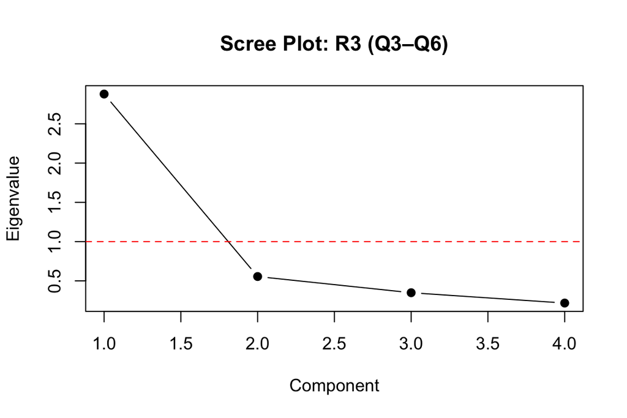

```r
plot(r3_eigen, type = "b", pch = 19,
     xlab = "Component", ylab = "Eigenvalue",
     main = "Scree Plot: R3 (Q3–Q6)")
abline(h = 1, lty = 2, col = "red")
```

```r
r3_pca <- principal(r3, nfactors = 1, rotate = "none")
print(r3_pca, digits = 2)
```

```
Principal Components Analysis
Call: principal(r = r3, nfactors = 1, rotate = "none")
Standardized loadings (pattern matrix) based upon correlation matrix
    PC1   h2   u2 com
q3 0.81 0.65 0.35   1
q4 0.91 0.83 0.17   1
q5 0.85 0.73 0.27   1
q6 0.81 0.66 0.34   1

                PC1
SS loadings    2.88
Proportion Var 0.72

Mean item complexity =  1
Test of the hypothesis that 1 component is sufficient.

The root mean square of the residuals (RMSR) is  0.08
 with the empirical chi square  9.12  with prob <  0.01

Fit based upon off diagonal values = 0.99
```

- **One component** emerges. Only the first eigenvalue is above 1 (2.88), and the scree plot drops off sharply after it.
- That single component explains **72% of the variance** in the four items.
- **Loadings are strong** for all items (.81 to .91), well above the usual .50 cutoff.
- **Communalities (h2) range from .65 to .83**, so the component captures most of each item’s variance. Q4 (helpful) is the strongest item at .83.

This supports **convergent validity**: the four items hang together as one “employee proficiency” construct.

### 3.3 Reliability

```r
r3_alpha <- alpha(r3)
r3_alpha
```

```
Reliability analysis
Call: alpha(x = r3)

  raw_alpha std.alpha G6(smc) average_r S/N   ase mean   sd median_r
      0.87      0.87    0.85      0.62 6.6 0.019  4.2 0.59     0.65

    95% confidence boundaries
         lower alpha upper
Feldt     0.82  0.87   0.9
Duhachek  0.83  0.87   0.9

 Reliability if an item is dropped:
   raw_alpha std.alpha G6(smc) average_r S/N alpha se   var.r med.r
q3      0.85      0.86    0.80      0.66 5.9    0.022 0.00056  0.67
q4      0.79      0.79    0.73      0.56 3.8    0.033 0.00800  0.57
q5      0.82      0.83    0.80      0.62 4.8    0.028 0.01894  0.67
q6      0.85      0.85    0.80      0.66 5.8    0.023 0.00610  0.68

 Item statistics
     n raw.r std.r r.cor r.drop mean   sd
q3 128  0.80  0.81  0.73   0.66  4.4 0.66
q4 128  0.91  0.91  0.88   0.82  4.3 0.70
q5 128  0.85  0.85  0.78   0.73  4.1 0.66
q6 128  0.83  0.82  0.73   0.67  4.1 0.79

Non missing response frequency for each item
      2    3    4    5 miss
q3 0.00 0.10 0.45 0.45    0
q4 0.01 0.11 0.45 0.44    0
q5 0.00 0.18 0.56 0.26    0
q6 0.03 0.18 0.47 0.32    0
```

- **Cronbach’s alpha = 0.87**, comfortably above the 0.70 benchmark, so the scale is internally consistent.
- **Alpha if item deleted:** removing any item lowers alpha (to .79–.85), so every item contributes and none should be dropped.
- **Item–total correlations (r.drop)** range from .66 to .82, which are all strong.

## 4 R6: Attitude Toward Operational Effectiveness (Q31–Q34)

### 4.1 Factorability

```r
round(cor(r6), 2)
```

```
     q31  q32  q33  q34
q31 1.00 0.28 0.12 0.00
q32 0.28 1.00 0.22 0.39
q33 0.12 0.22 1.00 0.04
q34 0.00 0.39 0.04 1.00
```

```r
KMO(r6)
```

```
Kaiser-Meyer-Olkin factor adequacy
Call: KMO(r = r6)
Overall MSA =  0.5
MSA for each item =
 q31  q32  q33  q34
0.49 0.50 0.60 0.46
```

```r
cortest.bartlett(cor(r6), n = nrow(r6))
```

```
$chisq
[1] 39.33432

$p.value
[1] 6.15472e-07

$df
[1] 6
```

This is where things start to look off.

- **Correlations are weak.** They range from .00 (Q31–Q34) to .39 (Q32–Q34). Q33 barely correlates with Q31 (.12) or Q34 (.04).
- **KMO = 0.50**, which is the lowest level that’s even considered acceptable (“miserable” by Kaiser’s labels). Q31 and Q34 have individual MSAs below .50.
- **Bartlett’s test** is still significant (χ² ≈ 39.3, p < .001). But with this sample size, that only tells me the items aren’t *completely* unrelated, not that they form one factor.

### 4.2 Convergent validity

```r
r6_eigen <- eigen(cor(r6))$values
round(r6_eigen, 3)
```

```
[1] 1.577 1.034 0.882 0.508
```

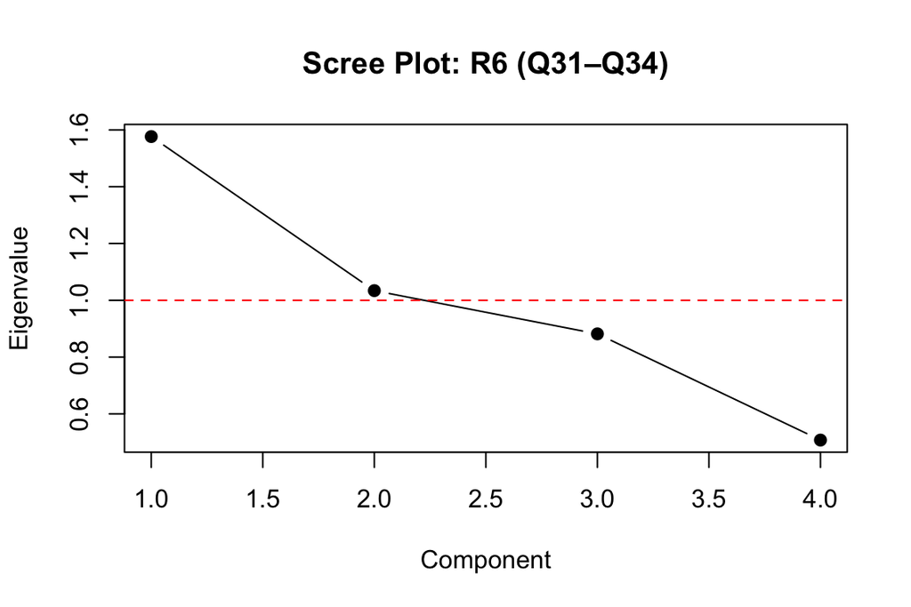

```r
plot(r6_eigen, type = "b", pch = 19,
     xlab = "Component", ylab = "Eigenvalue",
     main = "Scree Plot: R6 (Q31–Q34)")
abline(h = 1, lty = 2, col = "red")
```

```r
r6_pca1 <- principal(r6, nfactors = 1, rotate = "none")
print(r6_pca1, digits = 2)
```

```
Principal Components Analysis
Call: principal(r = r6, nfactors = 1, rotate = "none")
Standardized loadings (pattern matrix) based upon correlation matrix
     PC1   h2   u2 com
q31 0.51 0.26 0.74   1
q32 0.84 0.71 0.29   1
q33 0.48 0.23 0.77   1
q34 0.61 0.37 0.63   1

                PC1
SS loadings    1.58
Proportion Var 0.39

Mean item complexity =  1
Test of the hypothesis that 1 component is sufficient.

The root mean square of the residuals (RMSR) is  0.14
 with the empirical chi square  31.44  with prob <  1.5e-07

Fit based upon off diagonal values = 0.58
```

```r
r6_pca2 <- principal(r6, nfactors = 2, rotate = "varimax")
print(r6_pca2, digits = 2)
```

```
Principal Components Analysis
Call: principal(r = r6, nfactors = 2, rotate = "varimax")
Standardized loadings (pattern matrix) based upon correlation matrix
     RC1   RC2   h2   u2 com
q31 0.01  0.78 0.61 0.39 1.0
q32 0.72  0.46 0.73 0.27 1.7
q33 0.08  0.65 0.43 0.57 1.0
q34 0.91 -0.13 0.84 0.16 1.0

                       RC1  RC2
SS loadings           1.35 1.26
Proportion Var        0.34 0.32
Cumulative Var        0.34 0.65
Proportion Explained  0.52 0.48
Cumulative Proportion 0.52 1.00

Mean item complexity =  1.2
Test of the hypothesis that 2 components are sufficient.

The root mean square of the residuals (RMSR) is  0.14
 with the empirical chi square  29.46  with prob <  NA

Fit based upon off diagonal values = 0.61
```

So the R6 items **do not show convergent validity** as one “operational effectiveness” construct.

### 4.3 Reliability

```r
r6_alpha <- alpha(r6)
r6_alpha
```

```
Reliability analysis
Call: alpha(x = r6)

  raw_alpha std.alpha G6(smc) average_r  S/N   ase mean   sd median_r
      0.47      0.46    0.44      0.18 0.86 0.075  3.7 0.46     0.17

    95% confidence boundaries
         lower alpha upper
Feldt     0.30  0.47  0.61
Duhachek  0.33  0.47  0.62

 Reliability if an item is dropped:
    raw_alpha std.alpha G6(smc) average_r  S/N alpha se  var.r med.r
q31      0.47      0.46    0.40     0.219 0.84    0.080 0.0296 0.224
q32      0.14      0.15    0.11     0.056 0.18    0.131 0.0036 0.044
q33      0.47      0.46    0.42     0.223 0.86    0.079 0.0393 0.278
q34      0.44      0.44    0.35     0.208 0.79    0.084 0.0063 0.224

 Item statistics
      n raw.r std.r r.cor r.drop mean   sd
q31 128  0.54  0.57  0.30   0.19  3.9 0.68
q32 128  0.79  0.76  0.70   0.49  3.7 0.79
q33 128  0.53  0.56  0.27   0.19  3.6 0.68
q34 128  0.61  0.58  0.37   0.23  3.5 0.78

Non missing response frequency for each item
       1    2    3    4    5 miss
q31 0.01 0.00 0.21 0.60 0.18    0
q32 0.00 0.05 0.35 0.44 0.16    0
q33 0.00 0.05 0.35 0.54 0.05    0
q34 0.02 0.11 0.30 0.55 0.02    0
```

- **Cronbach’s alpha = 0.47**, well below 0.70, so the scale is **not reliable** as a four-item measure.
- **Alpha if item deleted:** dropping Q31, Q33, or Q34 doesn’t push alpha anywhere near 0.70 (it stays .44–.47). Dropping Q32 tanks it to .14, since Q32 is the only item holding the scale together.
- **Item–total correlations** for Q31, Q33, and Q34 are low (.19 to .23).

```r
# Does the strongest pair (Q32 + Q34) work on its own?
alpha(efcu[, c("q32", "q34")])$total[, c("raw_alpha", "std.alpha")]
```

```
 raw_alpha std.alpha
  0.559129 0.5591638
```

Even the strongest pair (Q32 + Q34) only reaches **alpha = 0.56**, so there’s no simple trimmed version of R6 that’s reliable.

## 5 Discriminant Validity: All Eight Items Together

```r
KMO(all8)$MSA
```

```
[1] 0.7956878
```

```r
round(eigen(cor(all8))$values, 3)
```

```
[1] 3.457 1.266 0.930 0.851 0.544 0.404 0.336 0.212
```

```r
all8_pca <- principal(all8, nfactors = 2, rotate = "varimax")
print(all8_pca$loadings, cutoff = 0, digits = 2)
```

```
Loadings:
    RC1   RC2
q3   0.78 -0.09
q4   0.88  0.11
q5   0.85  0.05
q6   0.80  0.19
q31  0.37  0.19
q32  0.38  0.75
q33  0.51  0.13
q34 -0.09  0.86

                RC1  RC2
SS loadings    3.29 1.43
Proportion Var 0.41 0.18
Cumulative Var 0.41 0.59
```

If both scales were valid and distinct, I’d expect Q3–Q6 to load on one component and Q31–Q34 on the other, with little crossover.

So R6 **lacks discriminant validity**. Two of its four items overlap more with employee proficiency than with operational effectiveness.

## 6 Summary of Results

| Check | R3: Employee Proficiency | R6: Operational Effectiveness |
| --- | --- | --- |
| Inter-item correlations | .46 – .72 (strong) | .00 – .39 (weak) |
| KMO | 0.78 ✅ | 0.50 ⚠️ |
| Bartlett’s test | p < .001 ✅ | p < .001 ✅ |
| Components (eigenvalue > 1) | 1 ✅ | 2 ❌ |
| Variance explained (1 component) | 72% ✅ | 39% ❌ |
| Loadings | .81 – .91 ✅ | .48 – .84 ⚠️ |
| Communalities | .65 – .83 ✅ | .23 – .71 ❌ |
| Discriminant validity (8-item EFA) | Clean ✅ | Q31 & Q33 cross over ❌ |
| Cronbach’s alpha | **0.87** ✅ | **0.47** ❌ |
| **Composite scale?** | **Yes** | **No** |

## 7 Implications for the Next Step in Analysis

**R3: Build a composite.** All four items load on one factor, explain most of the variance, stay distinct from the R6 items, and have strong reliability (α = .87). For the M13 analysis, I’ll average Q3–Q6 into one “employee proficiency” score and use that instead of four separate items. It’s simpler to report and more stable than any single item.

```r
efcu$employee_proficiency <- rowMeans(efcu[, r3_items])
summary(efcu$employee_proficiency)
```

```
   Min. 1st Qu.  Median    Mean 3rd Qu.    Max.
  2.750   4.000   4.000   4.205   4.750   5.000
```

**R6: Don’t build a composite.** The items split into two components, half of them overlap with the employee scale, and alpha (.47) is far below .70 with no item I can drop to fix it. Averaging them into one “operational effectiveness” score would combine things that don’t belong together and hide what’s really going on. For M13, I’ll **analyze Q31–Q34 as individual items** (frequencies, means, and comparisons per item). If a summary is needed, I’ll talk about the two themes (speed/ease vs. trust/fit) separately rather than reporting one combined number.

**One caveat:** R6 has only four items and a fairly small sample (n = 128), which makes weak correlations less stable. If EFCU runs this survey again, the operational effectiveness scale should be rewritten with more items that clearly focus on operations (processing speed, accuracy, ease of transactions) so it doesn’t blend into how members feel about employees.